# Curso de introducción a la programación con Python

**Autor: Luis Fernando Apáez Álvarez**

## Proyecto 1 (parte I): Graficador de funciones.

- Primer método
- Segundo método
- Tercero método

## Primer método

Sabemos que al considerar una función $f(x)$ podemos graficar ésta dando algunos valores representativos a la variable independiente $x$ para ver el comportamiento de $f(x)$. Por ejemplo, considerando la función $f(x)=x^{2}$ podemos considerar los valores

- $f(-2)=(-2)^{2}=4$ tendiendo así el par $(-2,4)$;
- $f(-1)=(-1)^{2}=1$ tendiendo así el par $(-1,1)$;
- $f(0)=0^{2}=0$ tendiendo así el par $(0,0)$;
- $f(1)=1^{2}=1$ tendiendo así el par $(1,1)$;
- $f(2)=2^{2}=4$ tendiendo así el par $(2,4)$;

lo cual nos brinda algunas parejas ordenadas que podemos graficar. A continuación graficaremos los puntos obtenidos, para ello importaremos el módulo necesario, que en este caso es `matplotlib.pyplot`; notemos que después de importar el módulo colocamos `as` el cual nos permite asignar un alias cuando ocupemos sentencias referentes a dicho módulo (el alias puede ser cualquiera, en nuestro caso colocamos `mplot`.). Después necesitaremos de dos sentencias básicas: `mplot.plot()` para graficar y `mplot.show()` para mostrar la gráfica creada. Dentro de los parámetros de `mplot.plot()` colocamos las coordenadas $(x,y)$ del punto que deseamos graficar seguido de `marker=""` para el tipo de marcador que deseamos utilizar; asimismo podemos agregar el color que deseamos utilizando `color=""`

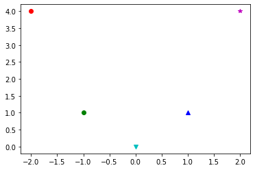

```python
import matplotlib.pyplot as mplot

mplot.plot(-2,4, marker="o", color="r")
mplot.plot(-1,1, marker="o", color="g")
mplot.plot(0,0, marker="v", color="c")
mplot.plot(1,1, marker="^", color="b")
mplot.plot(2,4, marker="*", color="m")
mplot.show()
```

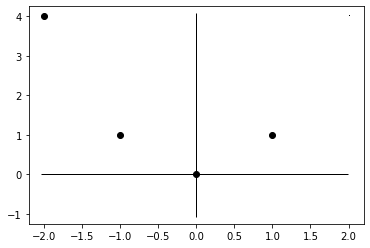

```python
# eje y

# inicialiamos la variable y
y = -1
# empleamos el bucle sobre el rango de valores en que estará el eje
while y <= 4 and y >= -1:
    mplot.plot(0,y, marker="|", color="k")
    y += 0.05

# ---------------------------------------------------------------------

# eje x
x = -2
while x <= 2 and x >= -2:
    mplot.plot(x,0, marker="_", color="k")
    x += 0.05

# ---------------------------------------------------------------------

mplot.plot(-2,4, marker="o", color="k")
mplot.plot(-1,1, marker="o", color="k")
mplot.plot(0,0, marker="o", color="k")
mplot.plot(1,1, marker="o", color="k")
mplot.plot(2,4, marker=".", color="k")
mplot.show()
```

Ahora, emplearemos la misma idea de cómo dibujamos los ejes para dibujar la gráfica de la función $f(x)=x^{2}$. Para evitar confución entre el manejo de la variables, reservaremos exclusivamente `x` y `y` para los ejes. De tal manera, si deseamos graficar $f(x)=y$, emplearemos el ajuste de las variables como $f(u)=v$. Así, la función que deseamos graficar es $f(u)={u^{2}}$:

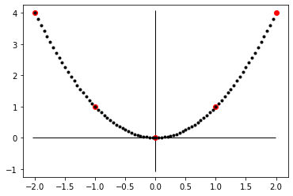

```python
# eje x
y = -1
while y <= 4 and y >= -1:
    mplot.plot(0,y, marker="|", color="k")
    y += 0.05

# ---------------------------------------------------------------------

# eje x
x = -2
while x <= 2 and x >= -2:
    mplot.plot(x,0, marker="_", color="k")
    x += 0.05

# ---------------------------------------------------------------------

# puntos obtenidos anteriormente
mplot.plot(-2,4, marker="o", color="r")
mplot.plot(-1,1, marker="o", color="r")
mplot.plot(0,0, marker="o", color="r")
mplot.plot(1,1, marker="o", color="r")
mplot.plot(2,4, marker="o", color="r")

# dibujo de la función f(u)=u^2

u = -2
while u <= 2 and u >= -2:
    mplot.plot(u,u ** 2, marker=".", color = "k")
    u += 0.05

mplot.show()
```

Nótese que aún no conseguimos que la función tome la forma de una curva, continúa viéndose como muchos puntos consecutivos. Para `marker="."` tenemos el tipo de marcador *punto* como puede verse en el gráfico anterior, dado que éstos puntos se ven un poco *gruesos* utilizaremos en cambio `marker=","` el cual marca un tipo de *pixel*.

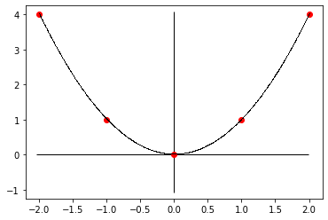

```python
# eje x
y = -1
while y <= 4 and y >= -1:
    mplot.plot(0,y, marker="|", color="k")
    y += 0.05

# ---------------------------------------------------------------------

# eje x
x = -2
while x <= 2 and x >= -2:
    mplot.plot(x,0, marker="_", color="k")
    x += 0.05

# ---------------------------------------------------------------------

# puntos obtenidos anteriormente
mplot.plot(-2,4, marker="o", color="r")
mplot.plot(-1,1, marker="o", color="r")
mplot.plot(0,0, marker="o", color="r")
mplot.plot(1,1, marker="o", color="r")
mplot.plot(2,4, marker="o", color="r")

# dibujo de la función f(u)=u^2

u = -2
while u <= 2 and u >= -2:
    mplot.plot(u,u ** 2, marker=",", color = "k")
    u += 0.005

mplot.show()
```

Podemos graficar otras funciones como:

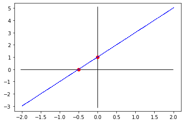

```python
# eje x
y = -3
while y <= 5 and y >= -3:
    mplot.plot(0,y, marker="|", color="k")
    y += 0.05

# ---------------------------------------------------------------------

# eje x
x = -2
while x <= 2 and x >= -2:
    mplot.plot(x,0, marker="_", color="k")
    x += 0.05

# ---------------------------------------------------------------------

# Algunos puntos
mplot.plot(0,1, marker="o", color="r")
mplot.plot(-0.5,0, marker="o", color="r")

# dibujo de la función f(u)=u^2

u = -2
while u <= 2 and u >= -2:
    mplot.plot(u,2 * u + 1, marker=",", color = "b")
    u += 0.005

mplot.show()
```

Ahora bien para acceder a más funciones matemáticas importaremos el módulo `math` y graficaremos las funciones $f(x)=sen(x)$, $g(x)=\sqrt{x}$ y $h(x)=ln(x)$:

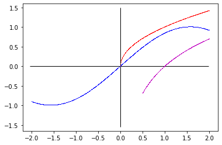

```python
import math
# ---------------------------------------------------------------------

# eje x
y = -1.5
while y <= 1.5 and y >= -1.5:
    mplot.plot(0,y, marker="|", color="k")
    y += 0.05

# ---------------------------------------------------------------------

# eje x
x = -2
while x <= 2 and x >= -2:
    mplot.plot(x,0, marker="_", color="k")
    x += 0.05

# ---------------------------------------------------------------------

# dibujo de la función f(u)=sen(u)

u1 = -2
while u1 <= 2 and u1 >= -2:
    mplot.plot(u1,math.sin(u1), marker=",", color = "b")
    u1 += 0.005

# dibujo de la función g(u)=sqrt(u)

u2 = 0
while u2 <= 2 and u2 >= -2:
    mplot.plot(u2,math.sqrt(u2), marker=",", color = "r")
    u2 += 0.005

# dibujo de la función h(u)=ln(u)

u3 = 0.5
while u3 <= 2 and u3 >= -2:
    mplot.plot(u3,math.log(u3), marker=",", color = "m")
    u3 += 0.005

mplot.show()
```

Podemos dibujar una circunferencia

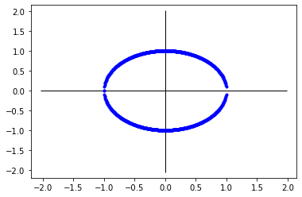

```python
# eje x
y = -2
while y <= 2 and y >= -2:
    mplot.plot(0,y, marker="|", color="k")
    y += 0.05

# ---------------------------------------------------------------------

# eje x
x = -2
while x <= 2 and x >= -2:
    mplot.plot(x,0, marker="_", color="k")
    x += 0.05

# ---------------------------------------------------------------------

# dibujo de la función f(u)=sen(u)

u4 = -1
while u4 <= 1 and u4 >= -1:
    mplot.plot(u4, math.sqrt(1 - u4 ** 2), marker=".", color = "b")
    u4 += 0.005

u5 = -1
while u5 <= 1 and u5 >= -1:
    mplot.plot(u5, - math.sqrt(1 - u5 ** 2), marker=".", color = "b")
    u5 += 0.005

mplot.show()
```

## Segundo método

El método anterior plantea un problema pues al realizar muchas iteraciones el tiempo de copilación aumentará. De hecho, el método empleado anteriormente es más ilustrativo que útil; a continuación utilizaremos el módulo `sympy`. Para ello

```python
from sympy import symbols
from sympy.plotting import plot
```

Ahora, recordemos que utilizamos `x` en Python como una variable a la cual podemos asignarle un valor e ir cambiando ese valor, pero en todo momento el valor que pueda tomar `x` debe estar declarado. Sin embargo, sabemos que en matemáticas podemos utilizar la variable $x$ que represente un número cualquiera sin especificar cuál es. Para trabajar con variables matemáticas en Python utilizaremos `symbols("")`. Por ejemplo, si deseamos considerar a `x` como una variable matemática hacemos que

```python
x = symbols("x")
```

Notemos que estamos trabajando con `x` sin haber declarado un valor previo como lo haciamos si deseabamos trabajar con la variable `x` dentro de Python. Ahora si podemos utilizar `x` como una variable del álgebra, por ejemplo podemos efectuar cálculos como $x+x$, $x\cdot x$, etcétera. En efecto

```python
print(x + x + x)
print(x + 2)
print(x * x * 2)
```

```
3*x
x + 2
2*x**2
```

Ahora bien, podemos graficar funciones de una manera más sencilla, por ejemplo

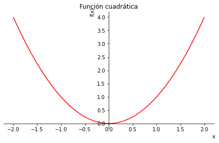

```
<sympy.plotting.plot.Plot at 0x209042b8388>
```

```python
x = symbols("x")

plot(x ** 2, (x, -2, 2), title="Función cuadrática", line_color="red")
```

donde dentro de `plot()` colocamos primero la función a graficar y después, entre paréntesis, colocamos el *símbolo* referente a la variable independiente matemática, seguido del intervalo donde graficaremos. Podemos graficar más funciones en un mismo plano:

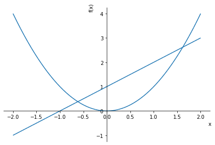

```
<sympy.plotting.plot.Plot at 0x20903b9dac8>
```

```python
plot(x ** 2, x + 1,(x, -2, 2))
```

o también agrupar las funciones a graficar junto con sus valores referentes al dominio de graficación entre paréntesis, esto es

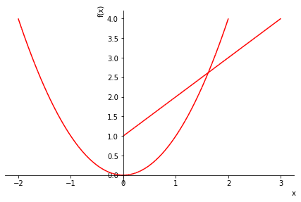

```
<sympy.plotting.plot.Plot at 0x20626d0f148>
```

```python
plot( (x ** 2, (x, -2, 2)), (x + 1, (x, 0, 3)), line_color = "red" )
```

## Tercer método

En realidad el tercer método es una afinación del primer método, de tal manera volveremos a utilizar el módulo `matplotlib` y además agregaremos el módulo `numpy`. Bien, lo primero que necesitamos para graficar una función es definir el dominio de graficación, para ello utilizamos

```python
import matplotlib.pyplot as mplot
import numpy as np

# definimos el rango adecuado

x = np.arange(-1,1, 0.01)
```

donde el rango de graficación será en el intervalo sobre $x$ de $[-1,1)$ con un incremento de $0.01$. Prosigamos graficando la función $f(x)=x^{3}$, para ello

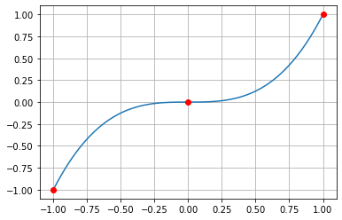

```python
x = np.arange(-1,1, 0.01)

# definimos la función f(x)=y

y = x ** 3

# creamos la gráfica

mplot.plot(x, y)

# agregamos algunos puntos

mplot.plot(0,0, marker="o", color="r")
mplot.plot(1,1, marker="o", color="r")
mplot.plot(-1,-1, marker="o", color="r")

# mostramos la cuadrícula en el gráfico (opcional)
mplot.grid()

# mostramos la gráfica
mplot.show()
```

Otro ejemplo:

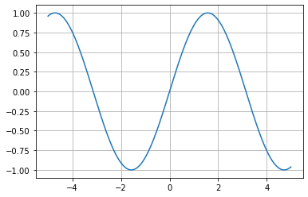

```python
# Definimos el rango de graficación

x = np.arange(-5,5, 0.01)

# definimos la función f(x)=y

y = np.sin(x)

# creamos la gráfica

mplot.plot(x, y)

# mostramos la cuadrícula en el gráfico (opcional)
mplot.grid()

# mostramos la gráfica
mplot.show()
```

Podemos agregar más funciones a la gráfica, por ejemplo

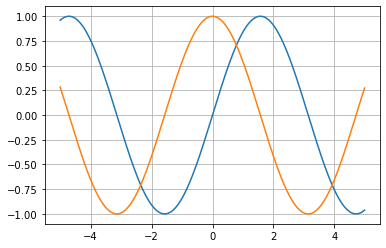

```python
# Definimos el rango de graficación

x = np.arange(-5,5, 0.01)

# definimos la primer función y1

y1 = np.sin(x)

# definimos la segunda función y2

y2 = np.cos(x)

# creamos la gráfica

mplot.plot(x, y1)
mplot.plot(x, y2)

# mostramos la cuadrícula en el gráfico (opcional)
mplot.grid()

# mostramos la gráfica
mplot.show()
```

Podemos cambiar el dominio de graficación de cada función:

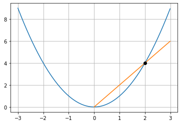

```python
# Definimos el rango de graficación de la primer función

x1 = np.arange(-3,3, 0.01)

# Definimos el rango de graficación de la segunda función

x2 = np.arange(0,3, 0.01)

# definimos la primer función y1

y1 = x1 ** 2

# definimos la segunda función y2

y2 = 2 * x2

# creamos la gráfica

mplot.plot(x1, y1)
mplot.plot(x2, y2)

# mostramos un punto

mplot.plot(2,4, marker = "o", color = "k")

# mostramos la cuadrícula en el gráfico (opcional)

mplot.grid()

# mostramos la gráfica
mplot.show()
```

Ahora, es posible agregar el título de un gráfico correspondiente, esto lo conseguimos utilizando `labe=""` dentro de `mplot.plot()` y para que dicho título se muestre usamos `mplot.legend()`:

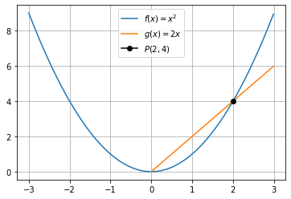

```python
x1 = np.arange(-3,3, 0.01)
x2 = np.arange(0,3, 0.01)

y1 = x1 ** 2
y2 = 2 * x2

# creamos la gráfica con los títulos correspondientes (podemos utilizar látex)

mplot.plot(x1, y1, label = "$f(x)=x^{2}$")
mplot.plot(x2, y2, label = "$g(x)=2x$")

# mostramos un punto

mplot.plot(2,4, marker = "o", color = "k", label = "$P(2,4)$")

# mostramos la cuadrícula en el gráfico (opcional)

mplot.grid()

# mostramos la gráfica con los títulos

mplot.legend()
mplot.show()
```